# Quasi-Newton Methods (BFGS) for Nonlinear Optimization

**Author**: v1.0 (May 2019) Jason Xie

1. Introduction  
   1.1 Data Preprocessing  
   1.2 Data Examination and Visualization
2. Problem Setup  
   2.1 Hypothesis Function  
   2.2 Objective Function  
   2.3 Gradient of the Objective Function  
   2.4 Initial Estimate of the Hessian Matrix
3. Experiments  
   3.1.1 BFGS  
   3.1.2 BFGS Visualization  
   3.2.1 L-BFGS  
   3.2.2 L-BFGS Visualization
4. Experimental Evaluation  
   4.1 Optimization Results  
   4.2 Convergence Rate Comparison  
   4.3 Discussion
5. Bibliography

## 1. Introduction

The BFGS (Broyden-Fletch-Goldfarb-Shanno) class of algorithms minimizes a given objective function by iteratively updating an initial parameter estimate $x^{(0)}$ with a scaled approximation of the inverse Hessian matrix $B^{(k)}$ (computed at every iteration) multipliedby the gradient $\nabla f^{(k)}$. Intuitively, each update improves upon the previous estimate $x^{(k)}$ by taking a step opposite the direction that of the function's growth (and therefore, in the direction of the objective function's minimum). For details of the algorithm, see Ch. 6, 7 of Nocedal and Wright (2006)<sup>[[1]](#1)</sup>.

This notebook implements the BFGS and L-BFGS (limited memory BFGS) algorithms for solving nonlinear optimization problems. It tests these methods on the nonlinear least squares regression problem, fitting an exponential class function to two strongly-blended Gaussians on a decaying exponential baseline plus normally distributed zero-mean noise with variance = 6.25<sup>[[2]](#2)</sup>.

```python
# Load libraries
from bfgs import bfgs_minimize
from l_bfgs import l_bfgs_minimize
import numpy as np
import torch
import matplotlib.pyplot as plt
%matplotlib inline

import urllib.request

from exutils.bfgs_utils import create_bfgs_vis
from IPython.display import HTML
```

### 1.1 Data Preprocessing

```python
# Load and process data
beta_i1_data = []
beta_i2_data = []
beta_fitted_data = []
p_data = []
r_data = []

with urllib.request.urlopen('https://www.itl.nist.gov/div898/strd/nls/data/LINKS/DATA/Gauss3.dat') as data:
    for _ in range(40):
        next(data)
    for _ in range(0, 8):
        line = data.readline()
        beta_i1_data.append(float(line.split()[2]))
        beta_i2_data.append(float(line.split()[3]))
        beta_fitted_data.append(float(line.split()[4]))
    for _ in range(48, 60):
        next(data)
    for line in data:
        r_data.append(float(line.split()[0]))
        p_data.append(float(line.split()[1]))

beta_i1 = np.array(np.transpose([beta_i1_data]))
beta_i2 = np.array(np.transpose([beta_i2_data]))
beta_fitted = np.array(np.transpose([beta_fitted_data]))
p = np.array(np.transpose([p_data]))
r = np.array(np.transpose([r_data]))
```

### 1.2 Data Examination and Visualization

```
Initial Parameters β1:  [9.49e+01 9.00e-03 9.01e+01 1.13e+02 2.00e+01 7.38e+01 1.40e+02 2.00e+01]
Initial Parameters β2:  [9.60e+01 9.60e-03 8.00e+01 1.10e+02 2.50e+01 7.40e+01 1.39e+02 2.50e+01]
Number of Observations: (250 predictors, 250 responses)
```

```
'Plot'
```

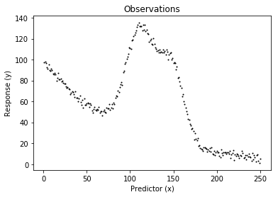

```python
# Output some information about the dataset
print('Initial Parameters \u03B21: ', np.transpose(beta_i1[:,0]))
print('Initial Parameters \u03B22: ', np.transpose(beta_i2[:,0]))
print('Number of Observations: (' + str(len(p)) + ' predictors, ' + str(len(r)) + ' responses)')

# Visualize observation pairs
plt.xlabel('Predictor (x)')
plt.ylabel('Response (y)')
plt.title('Observations')
plt.plot(p, r, 'ko', markersize=1)

'Plot'
```

## 2. Problem Setup

In the following section, we define several functions to set up the nonlinear least squares problem.

### 2.1 Hypothesis Function

This function returns the output of the predictive model for which we are attempting to find the best set of parameters, described by the exponential class:

#### $h_\beta(x) = \beta_1 e^{-\beta_2 x} + \beta_3 e^{-(x-\beta_4)^{2}/\beta_5^{2}} + \beta_6 e^{-(x-\beta_7)^{2}/\beta_8^{2}}$

```python
def eval_hyp_fn(data, beta):
    """Evaluates the output of the exponential class
    hypothesis function described by

    h_b(x) = b1*exp( -b2*x ) +
                b3*exp( -(x-b4)**2 / b5**2 ) +
                b6*exp( -(x-b7)**2 / b8**2 )
    """
    x = data[0]
    h = np.zeros(x.shape)
    for i in range(len(x)):
        h[i][0] = (beta[0] * np.exp(-beta[1] * x[i][0]) + \
                    beta[2] * np.exp(-(x[i][0] - beta[3])**2 / beta[4]**2) + \
                    beta[5] * np.exp(-(x[i][0] - beta[6])**2 / beta[7]**2))[0]
    return h
```

### 2.2 Objective Function

This function returns the output of the objective function we will attempt to minimize using BFGS. It is described by the sum of squared errors between the observed response variable and the prediction generated by the hypothesis function:

#### $f_\beta(x, y) = \vert\vert y - h_\beta(x) \vert\vert_2^{2}$

```python
def eval_obj_fn(data, beta):
    """Evaluates the objective function, defined by
    the square of the LSE of the hypothesis function
    """
    x, y = data[0], data[1]
    h = np.zeros(x.shape)
    for i in range(len(x)):
        h[i][0] = (beta[0] * np.exp(-beta[1] * x[i][0]) + \
                    beta[2] * np.exp(-(x[i][0] - beta[3])**2 / beta[4]**2) + \
                    beta[5] * np.exp(-(x[i][0] - beta[6])**2 / beta[7]**2))[0]
    return np.sum(np.square(y - h))
```

### 2.3 Gradient of the Objective Function

This function evaluates $\nabla f_\beta(x, y)$, the gradient of the objective function wrt. the parameters for which we are attempting to minimize.

```python
def eval_grad_obj(data, param_vals):
    """Returns the gradient f of the LSE residuals
    of the exponential class function wrt each parameter b_i
    """
    x = torch.tensor(data[0])
    y = torch.tensor(data[1])
    beta = torch.tensor(param_vals, requires_grad=True)
    f = beta[0] * torch.exp(-beta[1] * x) + \
         beta[2] * torch.exp(-(x - beta[3])**2 / beta[4]**2) + \
         beta[5] * torch.exp(-(x - beta[6])**2 / beta[7]**2)
    r = y - f
    r_lse = torch.sum(r**2)
    r_lse.backward()
    grads = beta.grad.numpy()
    return grads
```

### 2.4 Initial Estimate of the Hessian Matrix

This function initializes the approximate Hessian Matrix $B^{(0)}$ as $J^{T}J$, where $J$ is the Jacobian matrix of the residual loss function $r_\beta(x, y) = y - h_\beta(x)$. For further details, see Ch. 10 of Nocedal and Wright (2006)<sup>[[1]](#1)</sup>.

```python
def init_H(data, param_vals):
    """Evaluates the approximate Hessian of the objective function
    with the truncated Taylor polynomial using J^T * J
    """
    x = torch.tensor(data[0])
    y = torch.tensor(data[1])
    beta = torch.tensor(param_vals, requires_grad=True)
    jacobian = np.zeros((len(x), len(param_vals)))
    for i in range(len(x)):
        f_i = beta[0] * torch.exp(-beta[1] * x[i]) + \
         beta[2] * torch.exp(-(x[i] - beta[3])**2 / beta[4]**2) + \
         beta[5] * torch.exp(-(x[i] - beta[6])**2 / beta[7]**2)
        r = y[i] - f_i
        r.backward()
        grad_r = beta.grad.numpy()
        jacobian[i] = grad_r[:,0]
    return np.matmul(np.transpose(jacobian), jacobian)
```

## 3. Experiments

We perform BFGS and L-BFGS on the nonlinear least squares problem defined in 2. Problem Setup with initial parameters $\beta_1$ and $\beta_2$.

### 3.1.1 BFGS

Details of the implementation can be found in `bfgs.py`.

```python
# Test BFGS, first set of parameters
print('With initial parameters \u03B21: ')
min_beta_i1_bfgs, res_beta_i1_bfgs, params_beta_i1_bfgs = bfgs_minimize(eval_obj_fn,
                                                                        eval_grad_obj,
                                                                        beta_i1,
                                                                        init_H([p, r], beta_i1),
                                                                        [p,r],
                                                                        alpha=1.051,
                                                                        store_params=True)
```

```
With initial parameters β1:
The optimizer converged in 172 iterations.
Minimum value: 1244.4847202480705
```

```python
# Test BFGS, second set of parameters
print('With initial parameters \u03B22: ')
min_beta_i2_bfgs, res_beta_i2_bfgs, params_beta_i2_bfgs = bfgs_minimize(eval_obj_fn,
                                                                        eval_grad_obj,
                                                                        beta_i2,
                                                                        init_H([p, r], beta_i2),
                                                                        [p,r],
                                                                        alpha=0.101,
                                                                        store_params=True)
```

```
With initial parameters β2:
The optimizer converged in 368 iterations.
Minimum value: 1244.485486492761
```

### 3.1.2 BFGS Visualization

Visualize the evolution of the hypothesis function $h_\beta(x)$ with each iteration of BFGS:

```python
bfgs_vis1 = create_bfgs_vis(params_beta_i1_bfgs, eval_hyp_fn, [p,r], 'BFGS', '\u03B21')
HTML(bfgs_vis1.to_html5_video())
```

[video not shown]

```python
bfgs_vis2 = create_bfgs_vis(params_beta_i2_bfgs, eval_hyp_fn, [p,r], 'BFGS', '\u03B22')
HTML(bfgs_vis2.to_html5_video())
```

[video not shown]

### 3.2.1 L-BFGS

L-BFGS approximates $B^{(k)-1} \nabla f^{k}$ at each iteration with stored curvature information from only the last `m` updates, thereby reducing runtime as the full Hessian is not computed at each iteration.

We run L-BFGS with `m = 3`. Details of the implementation can be found in `l_bfgs.py`.

```python
# Test L-BFGS, first set of parameters
print('With initial parameters \u03B21: ')
min_beta_i1_lbfgs, res_beta_i1_lbfgs, params_beta_i1_lbfgs = l_bfgs_minimize(eval_obj_fn,
                                                                            eval_grad_obj,
                                                                            beta_i1,
                                                                            init_H([p, r], beta_i1),
                                                                            [p,r],
                                                                            m=3,
                                                                            alpha=1.051,
                                                                            store_params=True)
```

```
With initial parameters β1:
The optimizer converged in 19 iterations.
Minimum value: 1674.975929078831
```

```python
# Test L-BFGS, second set of parameters
print('With initial parameters \u03B22: ')
min_beta_i2_lbfgs, res_beta_i2_lbfgs, params_beta_i2_lbfgs = l_bfgs_minimize(eval_obj_fn,
                                                                            eval_grad_obj,
                                                                            beta_i2,
                                                                            init_H([p, r], beta_i2),
                                                                            [p,r],
                                                                            m=3,
                                                                            alpha=2.014,
                                                                            store_params=True)
```

```
With initial parameters β2:
The optimizer converged in 23 iterations.
Minimum value: 4052.83478405237
```

### 3.2.2 L-BFGS Visualization

Visualize the evolution of the hypothesis function $h_\beta(x)$ with each iteration of L-BFGS:

```python
lbfgs_vis1 = create_bfgs_vis(params_beta_i1_lbfgs, eval_hyp_fn, [p,r], 'L-BFGS', '\u03B21')
HTML(lbfgs_vis1.to_html5_video())
```

[video not shown]

```python
lbfgs_vis2 = create_bfgs_vis(params_beta_i2_lbfgs, eval_hyp_fn, [p,r], 'L-BFGS', '\u03B22')
HTML(lbfgs_vis2.to_html5_video())
```

[video not shown]

## 4. Experimental Evaluation

```python
# Best Fit with Certified Values
certified_fit = eval_hyp_fn([p, r], beta_fitted)
```

### 4.1 Optimization Results

```
'Plot'
```

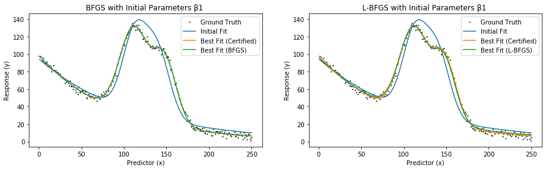

```python
# Optimization Results, Initial Parameters Beta_1
initial_y1 = eval_hyp_fn([p,r], beta_i1)
fitted_y1_bfgs = eval_hyp_fn([p,r], min_beta_i1_bfgs)
fitted_y1_lbfgs = eval_hyp_fn([p,r], min_beta_i1_lbfgs)

f = plt.figure(figsize=(15,4))
ax1 = f.add_subplot(1, 2, 1)
ax2 = f.add_subplot(1, 2, 2)
axes = [ax1, ax2]

for ax in axes:
    ax.set_xlabel('Predictor (x)')
    ax.set_ylabel('Response (y)')
    ax.plot(p, r, 'ko', markersize=1)
    ax.plot(p, initial_y1)
    ax.plot(p, certified_fit)

ax1.set_title('BFGS with Initial Parameters \u03B21 ')
ax1.plot(p, fitted_y1_bfgs)
ax1.legend(['Ground Truth', 'Initial Fit', 'Best Fit (Certified)', 'Best Fit (BFGS)'])

ax2.set_title('L-BFGS with Initial Parameters \u03B21 ')
ax2.plot(p, fitted_y1_lbfgs)
ax2.legend(['Ground Truth', 'Initial Fit', 'Best Fit (Certified)', 'Best Fit (L-BFGS)'])
```

```
'Plot'
```

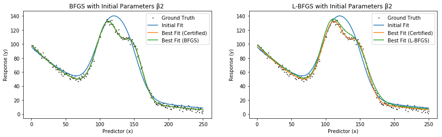

```python
# Optimization Results, Initial Parameters Beta_2
initial_y2 = eval_hyp_fn([p,r], beta_i2)
fitted_y2_bfgs = eval_hyp_fn([p,r], min_beta_i2_bfgs)
fitted_y2_lbfgs = eval_hyp_fn([p,r], min_beta_i2_lbfgs)

f = plt.figure(figsize=(15,4))
ax1 = f.add_subplot(1, 2, 1)
ax2 = f.add_subplot(1, 2, 2)
axes = [ax1, ax2]

for ax in axes:
    ax.set_xlabel('Predictor (x)')
    ax.set_ylabel('Response (y)')
    ax.plot(p, r, 'ko', markersize=1)
    ax.plot(p, initial_y2)
    ax.plot(p, certified_fit)

ax1.set_title('BFGS with Initial Parameters \u03B22 ')
ax1.plot(p, fitted_y2_bfgs)
ax1.legend(['Ground Truth', 'Initial Fit', 'Best Fit (Certified)', 'Best Fit (BFGS)'])

ax2.set_title('L-BFGS with Initial Parameters \u03B22 ')
ax2.plot(p, fitted_y2_lbfgs)
ax2.legend(['Ground Truth', 'Initial Fit', 'Best Fit (Certified)', 'Best Fit (L-BFGS)'])
```

### 4.2 Convergence Rate Comparison

```python
# Benchmarking batch gradient descent on the nonlinear least squares regression problem
from gd import gradientDescent_minimize

_, res_beta_i1_bgd, _ = gradientDescent_minimize(eval_obj_fn,
                                                 eval_grad_obj,
                                                 beta_i1,
                                                 [p,r],
                                                 store_params=True,
                                                 max_iterations=200)

_, res_beta_i2_bgd, _ = gradientDescent_minimize(eval_obj_fn,
                                                 eval_grad_obj,
                                                 beta_i2,
                                                 [p,r],
                                                 store_params=True,
                                                 max_iterations=400)
```

```
The optimizer did not converge in 200 iterations.
Best minimum approximation: 22797.074183222918
The optimizer did not converge in 400 iterations.
Best minimum approximation: 14909.56727984859
```

```
'Plot'
```

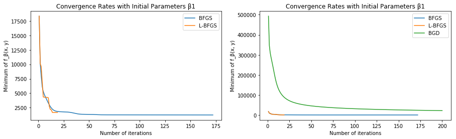

```python
# Convergence Results, Initial Parameters Beta_1
f = plt.figure(figsize=(15,4))
ax1 = f.add_subplot(1, 2, 1)
ax2 = f.add_subplot(1, 2, 2)
axes = [ax1, ax2]

for ax in axes:
    ax.set_xlabel('Number of iterations')
    ax.set_ylabel('Minimum of f_\u03B2(x, y)')
    ax.set_title('Convergence Rates with Initial Parameters \u03B21')
    ax.plot(range(1, len(res_beta_i1_bfgs)+1), res_beta_i1_bfgs[0:])
    ax.plot(range(1, len(res_beta_i1_lbfgs)+1), res_beta_i1_lbfgs[0:])

ax1.legend(['BFGS', 'L-BFGS'])

ax2.plot(range(1, len(res_beta_i1_bgd)+1), res_beta_i1_bgd[0:])
ax2.legend(['BFGS', 'L-BFGS', 'BGD'])
```

```
'Plot'
```

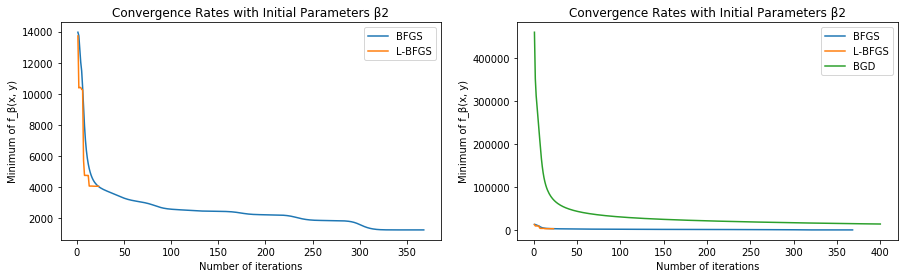

```python
# Convergence Results, Initial Parameters Beta_2
f = plt.figure(figsize=(15,4))
ax1 = f.add_subplot(1, 2, 1)
ax2 = f.add_subplot(1, 2, 2)
axes = [ax1, ax2]

for ax in axes:
    ax.set_xlabel('Number of iterations')
    ax.set_ylabel('Minimum of f_\u03B2(x, y)')
    ax.set_title('Convergence Rates with Initial Parameters \u03B22')
    ax.plot(range(1, len(res_beta_i2_bfgs)+1), res_beta_i2_bfgs[0:])
    ax.plot(range(1, len(res_beta_i2_lbfgs)+1), res_beta_i2_lbfgs[0:])

ax1.legend(['BFGS', 'L-BFGS'])

ax2.plot(range(1, len(res_beta_i2_bgd)+1), res_beta_i2_bgd[0:])
ax2.legend(['BFGS', 'L-BFGS', 'BGD'])
```

### 4.3 Discussion

As L-BFGS does not have access to the full Hessian matrix, the search direction $B^{(k) -1} \nabla f^{(k)}$ varies more frequently between iterations and is thus more sensitive to the behavior of the objective function in the last $m$ iterations. Varying the initial choice of the step-size $\alpha$ tends to yield more significant differences in the resulting minimized function for L-BFGS than in BFGS, particularly for small values of m. Although these factors prevent L-BFGS from always finding a global minimum in practice, it nonetheless manages reasonable performance similar to that of BFGS in early iterations, and depending on the behavior of the objective function in certain windows it may also converge more quickly than BFGS.

A comparison between the BFGS class of algorithms and the batch gradient descent algorithm demonstrates that second order hill climbing techniques are more expressive than first order hill climbing techniques. Indeed, on the nonlinear least squares problem defined in 2. Problem Setup the BFGS class of algorithms produces a better initialization and convergences significantly more quickly batch gradient descent.

## 5. Bibliography

[1] Numerical Optimization (Jorge Nocedal and Stephen J. Wright), Springer, 2006.

[2] Rust, B., NIST (1996).